# Task 1: Dataset Characterization and Preprocessing

## Explore the dataset: Before preprocessing the data, explore the data to understand the available features.

```python
# load data from csv file
import pandas as pd
# load training and test data
df = pd.read_csv('./train.csv')
df_test = pd.read_csv('./test.csv')
```

```python
# display summary of the training data
rows_columns = df.shape
print(f"Number of rows: {rows_columns[0]}, Number of columns: {rows_columns[1]}")

summary_df = pd.DataFrame({
    'Data Type': df.dtypes,
    'Unique Values': df.nunique(),
})
print(summary_df)
```

```
Number of rows: 18831, Number of columns: 43
                            Data Type  Unique Values
duration                        int64            750
protocol_type                  object              3
service                        object             65
flag                           object             11
src_bytes                       int64           1657
dst_bytes                       int64           3901
land                            int64              2
wrong_fragment                  int64              3
urgent                          int64              1
hot                             int64             21
num_failed_logins               int64              5
logged_in                       int64              2
num_compromised                 int64             27
root_shell                      int64              2
su_attempted                    int64              3
num_root                        int64             25
num_file_creations              int64             19
num_shells                      int64              2
num_access_files                int64              7
num_outbound_cmds               int64              1
is_host_login                   int64              1
is_guest_login                  int64              2
count                           int64            466
srv_count                       int64            414
serror_rate                   float64             65
srv_serror_rate               float64             43
rerror_rate                   float64             72
srv_rerror_rate               float64             42
same_srv_rate                 float64             94
diff_srv_rate                 float64             79
srv_diff_host_rate            float64             57
dst_host_count                  int64            256
dst_host_srv_count              int64            256
dst_host_same_srv_rate        float64            101
dst_host_diff_srv_rate        float64            101
dst_host_same_src_port_rate   float64            101
dst_host_srv_diff_host_rate   float64             63
dst_host_serror_rate          float64            100
dst_host_srv_serror_rate      float64             76
dst_host_rerror_rate          float64            101
dst_host_srv_rerror_rate      float64            100
label                          object              4
binary_label                    int64              2
```

```python
 # check Missing Values
missing_values = df.isnull().sum()
print("\nMissing Values:")
print(missing_values)

# Duplicates: Are there identical rows that might bias your model?
duplicate_rows = df.duplicated().sum()
print(f"\nNumber of duplicate rows: {duplicate_rows}")
```

```
Missing Values:
duration                       0
protocol_type                  0
service                        0
flag                           0
src_bytes                      0
dst_bytes                      0
land                           0
wrong_fragment                 0
urgent                         0
hot                            0
num_failed_logins              0
logged_in                      0
num_compromised                0
root_shell                     0
su_attempted                   0
num_root                       0
num_file_creations             0
num_shells                     0
num_access_files               0
num_outbound_cmds              0
is_host_login                  0
is_guest_login                 0
count                          0
srv_count                      0
serror_rate                    0
srv_serror_rate                0
rerror_rate                    0
srv_rerror_rate                0
same_srv_rate                  0
diff_srv_rate                  0
srv_diff_host_rate             0
dst_host_count                 0
dst_host_srv_count             0
dst_host_same_srv_rate         0
dst_host_diff_srv_rate         0
dst_host_same_src_port_rate    0
dst_host_srv_diff_host_rate    0
dst_host_serror_rate           0
dst_host_srv_serror_rate       0
dst_host_rerror_rate           0
dst_host_srv_rerror_rate       0
label                          0
binary_label                   0
dtype: int64

Number of duplicate rows: 0
```

```python
# display average, standard deviation, min, max, and quartiles for numeric columns
print(df.describe())
```

```
           duration     src_bytes     dst_bytes          land  wrong_fragment  \
count  18831.000000  1.883100e+04  1.883100e+04  18831.000000    18831.000000
mean     407.959057  3.254533e+04  3.238093e+03      0.000053        0.029844
std     3100.606651  2.788382e+06  5.902675e+04      0.007287        0.297558
min        0.000000  0.000000e+00  0.000000e+00      0.000000        0.000000
25%        0.000000  8.000000e+00  0.000000e+00      0.000000        0.000000
50%        0.000000  2.070000e+02  1.360000e+02      0.000000        0.000000
75%        0.000000  3.140000e+02  1.307500e+03      0.000000        0.000000
max    42862.000000  3.817091e+08  5.131424e+06      1.000000        3.000000

        urgent           hot  num_failed_logins     logged_in  \
count  18831.0  18831.000000       18831.000000  18831.000000
mean       0.0      0.261324           0.001062      0.527269
std        0.0      2.481723           0.047216      0.499269
min        0.0      0.000000           0.000000      0.000000
25%        0.0      0.000000           0.000000      0.000000
50%        0.0      0.000000           0.000000      1.000000
75%        0.0      0.000000           0.000000      1.000000
max        0.0     77.000000           4.000000      1.000000

       num_compromised  ...  dst_host_srv_count  dst_host_same_srv_rate  \
count     18831.000000  ...        18831.000000            18831.000000
mean          0.301630  ...          149.129149                0.672539
std          12.044815  ...          108.178912                0.416083
min           0.000000  ...            0.000000                0.000000
25%           0.000000  ...           21.000000                0.170000
50%           0.000000  ...          188.000000                1.000000
75%           0.000000  ...          255.000000                1.000000
max         884.000000  ...          255.000000                1.000000

       dst_host_diff_srv_rate  dst_host_same_src_port_rate  \
count            18831.000000                 18831.000000
mean                 0.087955                     0.194628
std                  0.215677                     0.341369
min                  0.000000                     0.000000
25%                  0.000000                     0.000000
50%                  0.010000                     0.010000
75%                  0.060000                     0.180000
max                  1.000000                     1.000000

```

[output cut: 16 more lines]

```
50%                    0.000000              0.000000
75%                    0.000000              0.000000
max                    1.000000              1.000000

       dst_host_srv_rerror_rate  binary_label
count              18831.000000  18831.000000
mean                   0.103238      0.285858
std                    0.295504      0.451834
min                    0.000000      0.000000
25%                    0.000000      0.000000
50%                    0.000000      0.000000
75%                    0.000000      1.000000
max                    1.000000      1.000000

[8 rows x 39 columns]
```

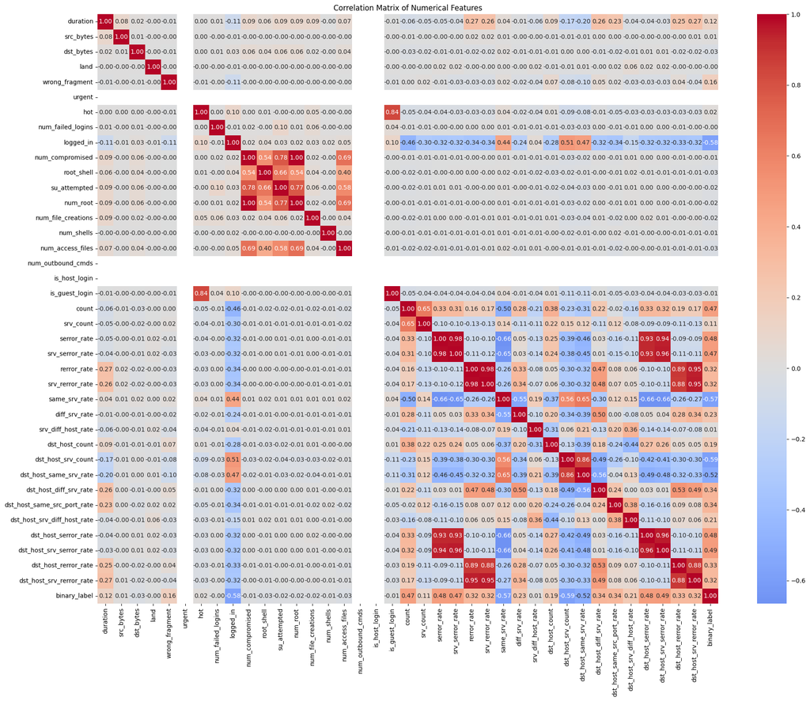

```python
# check correlations between numeric features
import numpy as np
import seaborn as sns
import matplotlib.pyplot as plt
correlation_matrix = df.select_dtypes(include=[np.number]).corr()

# Create heatmap
plt.figure(figsize=(20, 16))
sns.heatmap(correlation_matrix, annot=True, cmap='coolwarm', center=0, fmt='.2f')
plt.title('Correlation Matrix of Numerical Features')
plt.tight_layout()
plt.show()
plt.close()
```

```python
# display sample of the training data
print("\nSample of training data:")
print(df.head(5))
```

```
Sample of training data:
   duration protocol_type  service flag  src_bytes  dst_bytes  land  \
0         0           udp  private   SF         28          0     0
1         0          icmp    eco_i   SF          8          0     0
2         0           tcp  daytime   S0          0          0     0
3         0           tcp     http   SF        216       3396     0
4         0           tcp     http   SF        348        277     0

   wrong_fragment  urgent  hot  ...  dst_host_same_srv_rate  \
0               3       0    0  ...                    0.36
1               0       0    0  ...                    1.00
2               0       0    0  ...                    0.02
3               0       0    0  ...                    1.00
4               0       0    0  ...                    1.00

```

[output cut: 29 more lines]

### Q:How are your attack labels and binary label distributed?

```python
import matplotlib.pyplot as plt
import seaborn as sns
import pandas as pd
import os

def plot_single_distribution(df, column_name, save_pdf=True):
    """
    Plots a bar chart with counts and percentages, prints a summary,
    and saves the resulting plot as a PDF file.
    """
    # --- 1. Data Calculation ---
    counts = df[column_name].value_counts()
    percentages = df[column_name].value_counts(normalize=True) * 100
    summary = pd.DataFrame({'Count': counts, 'Percentage (%)': percentages.round(2)})

    # Print the summary table to the console for quick reference
    print(f"\n--- Distribution Summary: {column_name} ---")
    print(summary)
    print("-" * 40)

    # --- 2. Plotting Setup ---
    sns.set_theme(style="whitegrid")
    num_categories = len(counts)
    # Dynamically scale width based on number of categories
    plt.figure(figsize=(max(10, num_categories * 0.8), 7))

    # --- 3. Create Bar Chart ---
    order = counts.index
    ax = sns.countplot(data=df, x=column_name, palette='viridis', order=order)

    plt.title(f'Distribution Analysis: {column_name}', fontsize=16, fontweight='bold')
    plt.xlabel('Category', fontsize=12)
    plt.ylabel('Total Samples', fontsize=12)

    # --- 4. Annotate Bars (Count + Percentage) ---
    total = len(df)
    for p in ax.patches:
        height = p.get_height()
        if height > 0: # Only annotate if there's data
            percentage = f'{(100 * height / total):.1f}%'
            ax.annotate(f'{int(height)}\n({percentage})',
                        (p.get_x() + p.get_width() / 2., height),
                        ha='center', va='bottom',
                        xytext=(0, 5),
                        textcoords='offset points',
                        fontsize=10,
                        fontweight='bold')

    # --- 5. Rotation for many categories ---
    if num_categories > 5:
        plt.xticks(rotation=45, ha='right')

    plt.tight_layout()

    # --- 6. Save as PDF ---

    if save_pdf:
        # if the "plots" directory doesn't exist, create it
        os.makedirs("plots", exist_ok=True)

        filename = f"distribution_{column_name}.pdf"
        # use os.path.join to ensure correct path formatting across different operating systems
        file_path = os.path.join("plots", filename)

        plt.savefig(file_path, format='pdf', bbox_inches='tight')
        print(f"✅ Successfully saved plot to: {file_path}")

    # --- 7. Show Plot ---
    plt.show()
```

```
--- Distribution Summary: label ---
        Count  Percentage (%)
label
normal  13448           71.41
dos      2913           15.47
probe    2289           12.16
r2l       181            0.96
----------------------------------------
```

```
✅ Successfully saved plot to: plots/distribution_label.pdf
```

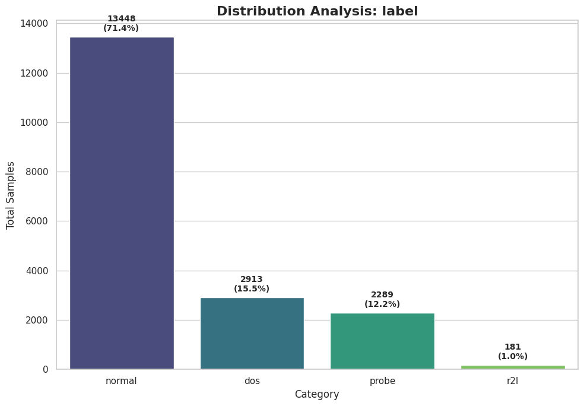

```
--- Distribution Summary: binary_label ---
              Count  Percentage (%)
binary_label
0             13448           71.41
1              5383           28.59
----------------------------------------
✅ Successfully saved plot to: plots/distribution_binary_label.pdf
```

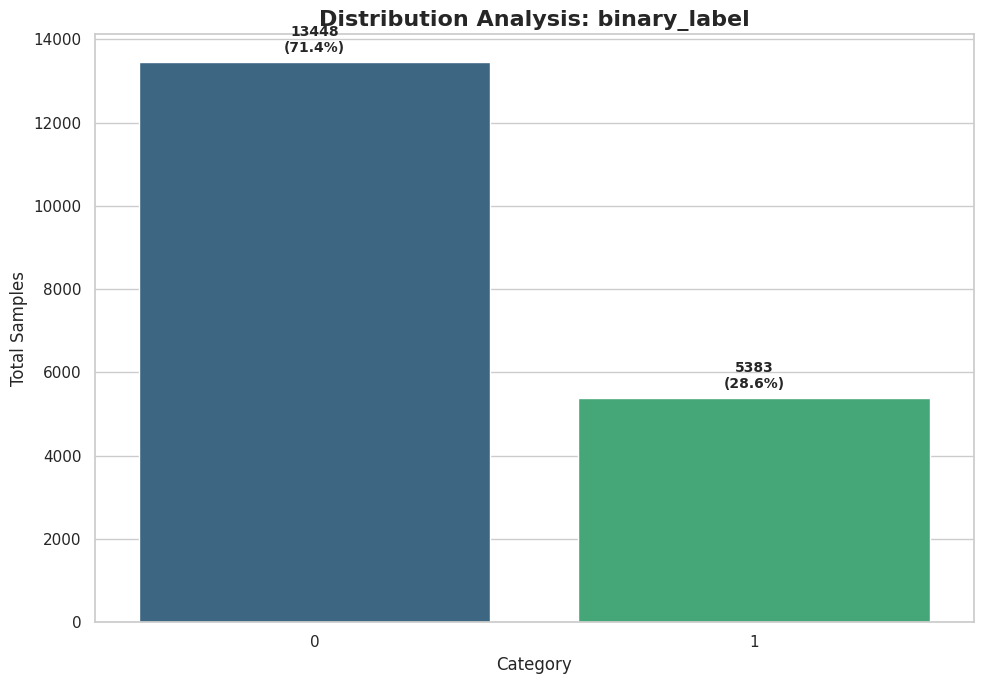

```
--- Distribution Summary: protocol_type ---
               Count  Percentage (%)
protocol_type
tcp            14204           75.43
udp             3010           15.98
icmp            1617            8.59
----------------------------------------
```

```
✅ Successfully saved plot to: plots/distribution_protocol_type.pdf
```

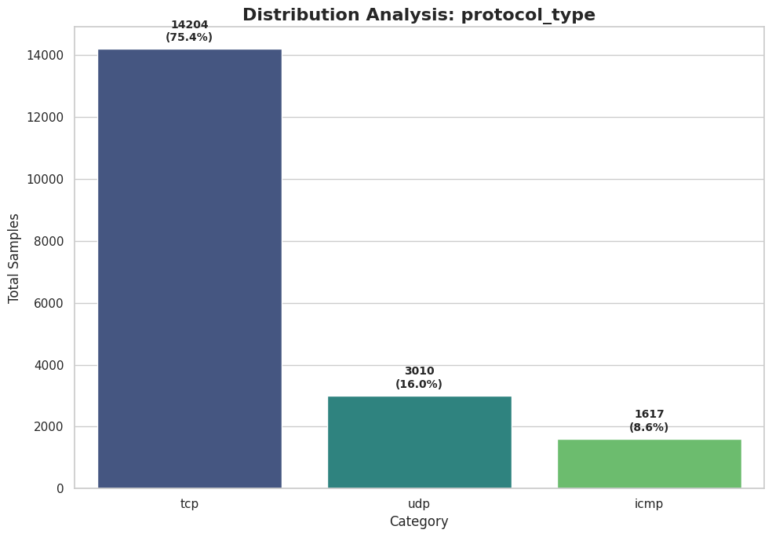

```
--- Distribution Summary: service ---
          Count  Percentage (%)
service
http       7831           43.85
private    2036           11.40
domain_u   1820           10.19
smtp       1411            7.90
ftp_data   1191            6.67
eco_i       909            5.09
other       855            4.79
ecr_i       577            3.23
telnet      268            1.50
ftp         263            1.47
finger      193            1.08
urp_i       124            0.69
auth         75            0.42
time         59            0.33
bgp          43            0.24
pop_3        42            0.24
uucp         41            0.23
Z39_50       40            0.22
IRC          40            0.22
nnsp         40            0.22
----------------------------------------
```

```
✅ Successfully saved plot to: plots/distribution_service.pdf
```

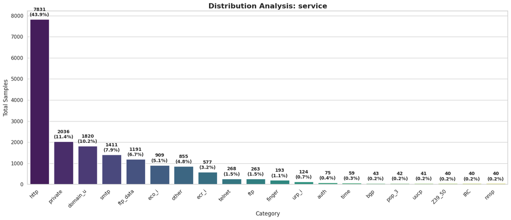

```
--- Distribution Summary: flag ---
        Count  Percentage (%)
flag
SF      14907           79.16
S0       1765            9.37
REJ      1359            7.22
RSTR      497            2.64
RSTO      112            0.59
S1         87            0.46
SH         42            0.22
S2         21            0.11
RSTOS0     21            0.11
S3         15            0.08
OTH         5            0.03
----------------------------------------
```

```
✅ Successfully saved plot to: plots/distribution_flag.pdf
```

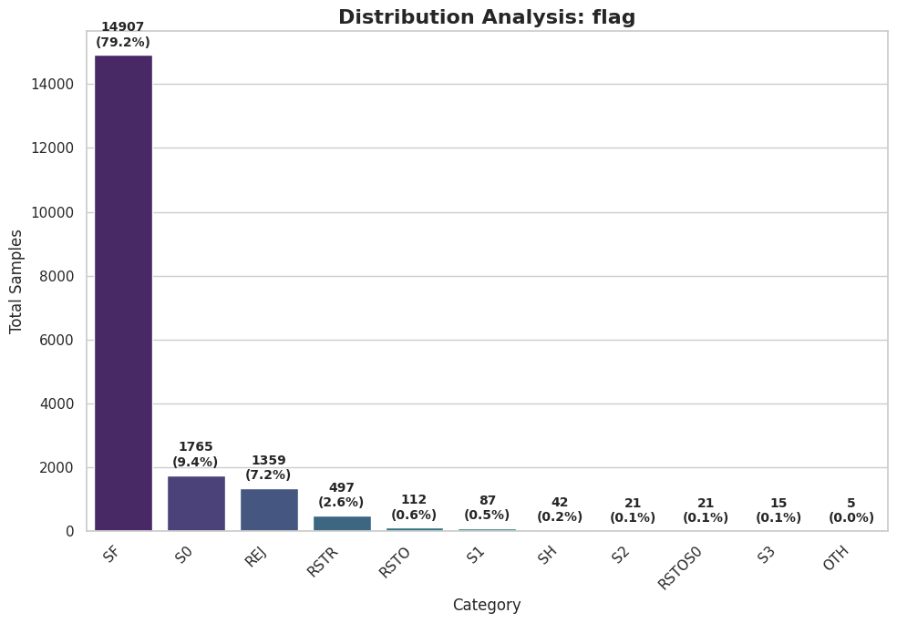

```python
plot_single_distribution(df, 'label')
plot_single_distribution(df, 'binary_label')
plot_single_distribution(df, 'protocol_type')
top_20_services = df[df['service'].isin(df['service'].value_counts().head(20).index)]
plot_single_distribution(top_20_services, 'service')
plot_single_distribution(df, 'flag')
```

## Preprocessing: Preprocess your features before performing any AI/ML algorithms.

### Drop useless features

```python
#hree columns have 0 variance (only 1 unique value) and provide no information:urgent, num outbound cmds, and is host login.
features_to_drop = ["urgent", "num_outbound_cmds", "is_host_login"]
df.drop(columns=features_to_drop, inplace=True)
df_test.drop(columns=features_to_drop, inplace=True)
print(f"Dropped features: {features_to_drop}")
print("\nUpdated training data shape:", df.shape)
print("Updated test data shape:", df_test.shape)
```

```
Dropped features: ['urgent', 'num_outbound_cmds', 'is_host_login']

Updated training data shape: (18831, 40)
Updated test data shape: (5826, 40)
```

### Reduce the number of possibile categories for each categorical feature

```
--- Distribution Summary: service ---
          Count  Percentage (%)
service
http       7831           41.59
other      2525           13.41
private    2036           10.81
domain_u   1820            9.66
smtp       1411            7.49
ftp_data   1191            6.32
eco_i       909            4.83
ecr_i       577            3.06
telnet      268            1.42
ftp         263            1.40
----------------------------------------
✅ Successfully saved plot to: plots/distribution_service.pdf
```

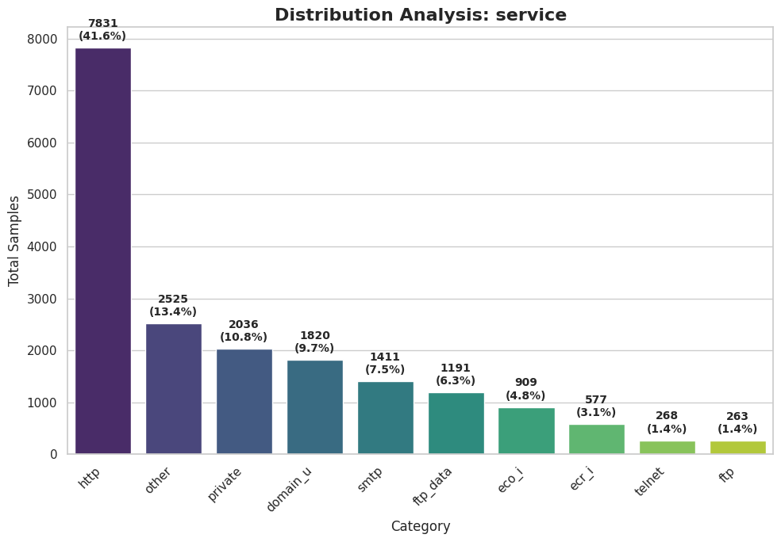

```
--- Distribution Summary: flag ---
       Count  Percentage (%)
flag
SF     14907           79.16
S0      1765            9.37
REJ     1359            7.22
other    800            4.25
----------------------------------------
```

```
✅ Successfully saved plot to: plots/distribution_flag.pdf
```

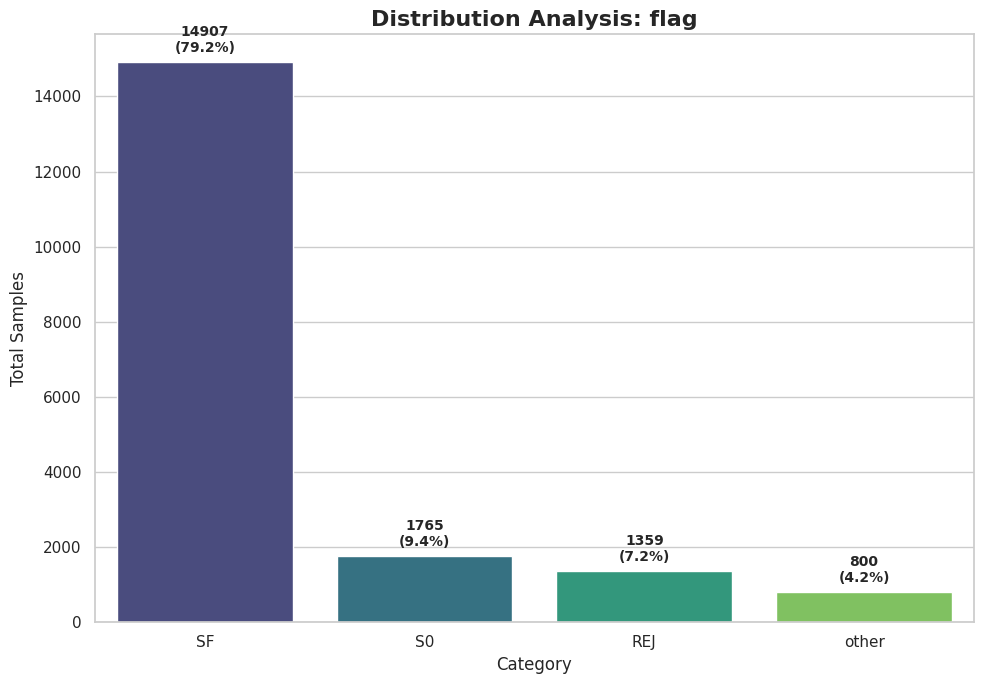

```python
allowed_services = [
    "http", "private", "domain_u", "smtp", "ftp_data",
    "eco_i", "other", "ecr_i", "telnet", "ftp"
]
df["service"] = df["service"].apply(lambda x: x if x in allowed_services else "other")
df_test["service"] = df_test["service"].apply(lambda x: x if x in allowed_services else "other")
plot_single_distribution(df, 'service')

# Define the allowed list of flags
allowed_flag = ["SF", "S0", "REJ"]
df["flag"]   = df["flag"].apply(lambda x: x if x in allowed_flag else "other")
df_test["flag"]       = df_test["flag"].apply(lambda x: x if x in allowed_flag else "other")
plot_single_distribution(df, 'flag')
```

```python
#remove duplicates in the training data

initial_row_count = df.shape[0]
df.drop_duplicates(inplace=True)
final_row_count = df.shape[0]
duplicates_removed = initial_row_count - final_row_count
print(f"Removed {duplicates_removed} duplicate rows. Final row count: {final_row_count}")

#remove duplicates in the test data
initial_test_row_count = df_test.shape[0]
df_test.drop_duplicates(inplace=True)
final_test_row_count = df_test.shape[0]
test_duplicates_removed = initial_test_row_count - final_test_row_count
print(f"Removed {test_duplicates_removed} duplicate rows from test data. Final test row count: {final_test_row_count}")

#remove missing values
df.dropna(inplace=True)
print(f"After removing missing values, final row count: {df.shape[0]}")
df_test.dropna(inplace=True)
print(f"After removing missing values from test data, final row count: {df_test.shape[0]}")

# Remove infinite and negative values
numeric_cols = df.select_dtypes(include=[np.number]).columns
for col in numeric_cols:
    df = df[np.isfinite(df[col])]
    df = df[df[col] >= 0]
print(f"After removing infinite and negative values, final row count: {df.shape[0]}")
numeric_test_cols = df_test.select_dtypes(include=[np.number]).columns
for col in numeric_test_cols:
    df_test = df_test[np.isfinite(df_test[col])]
    df_test = df_test[df_test[col] >= 0]
print(f"After removing infinite and negative values from test data, final row count: {df_test.shape[0]}")
```

[output not shown]

### split dataset into train and validation sets

```python
from sklearn.model_selection import train_test_split
df_train, df_val = train_test_split(df, train_size=0.9, stratify=df["binary_label"], random_state=42)
print(f"Training set shape: {df_train.shape}")
print(f"Validation set shape: {df_val.shape}")
```

```
Training set shape: (16917, 40)
Validation set shape: (1880, 40)
```

### perform nomorlization and encoding

```python
import numpy as np
from sklearn.compose import ColumnTransformer
from sklearn.preprocessing import OneHotEncoder, StandardScaler

#Perform feature normalization and process categorical and numerical features simultaneously

# === 1. Set up column groups ===
ignore_cols = ['label', 'binary_label']  # columns to skip entirely
categorical_cols = ['protocol_type', 'service', 'flag']
numerical_cols = [col for col in df_train.columns if col not in categorical_cols + ignore_cols]

# === 2. Define ColumnTransformer ===
preprocessor = ColumnTransformer(
    transformers=[
        ('num', StandardScaler(), numerical_cols),
        ('cat', OneHotEncoder(handle_unknown='ignore', sparse_output=False), categorical_cols)
    ],
    remainder='drop'  # drop columns not listed (i.e., ignore_cols)
)

# === 3. Fit on training, transform all splits ===
X_train_transformed = preprocessor.fit_transform(df_train)
X_val_transformed   = preprocessor.transform(df_val)
X_test_transformed  = preprocessor.transform(df_test)

# === 4. Optional: Get transformed feature names and make DataFrames ===
cat_feature_names = preprocessor.named_transformers_['cat'].get_feature_names_out(categorical_cols)
all_feature_names = list(numerical_cols) + list(cat_feature_names)

df_train_preprocessed = pd.DataFrame(X_train_transformed, columns=all_feature_names)
df_val_preprocessed   = pd.DataFrame(X_val_transformed, columns=all_feature_names)
df_test_preprocessed  = pd.DataFrame(X_test_transformed, columns=all_feature_names)



# === 5. Restore the labels ===
df_train_preprocessed["label"] = list(df_train["label"])
df_val_preprocessed["label"]   = list(df_val["label"])
df_test_preprocessed["label"]  = list(df_test["label"])

df_train_preprocessed["binary_label"] = list(df_train["binary_label"])
df_val_preprocessed["binary_label"]   = list(df_val["binary_label"])
df_test_preprocessed["binary_label"]  = list(df_test["binary_label"])

print("Preprocessing complete. Sample of preprocessed training data:")
print(df_train_preprocessed.shape)
print(df_train_preprocessed.dtypes)
```

```
Preprocessing complete. Sample of preprocessed training data:
(16917, 54)
duration                       float64
src_bytes                      float64
dst_bytes                      float64
land                           float64
wrong_fragment                 float64
hot                            float64
num_failed_logins              float64
logged_in                      float64
num_compromised                float64
root_shell                     float64
su_attempted                   float64
num_root                       float64
num_file_creations             float64
num_shells                     float64
num_access_files               float64
is_guest_login                 float64
count                          float64
srv_count                      float64
serror_rate                    float64
srv_serror_rate                float64
rerror_rate                    float64
srv_rerror_rate                float64
same_srv_rate                  float64
diff_srv_rate                  float64
srv_diff_host_rate             float64
dst_host_count                 float64
dst_host_srv_count             float64
dst_host_same_srv_rate         float64
dst_host_diff_srv_rate         float64
dst_host_same_src_port_rate    float64
dst_host_srv_diff_host_rate    float64
dst_host_serror_rate           float64
dst_host_srv_serror_rate       float64
dst_host_rerror_rate           float64
dst_host_srv_rerror_rate       float64
protocol_type_icmp             float64
protocol_type_tcp              float64
protocol_type_udp              float64
service_domain_u               float64
service_eco_i                  float64
service_ecr_i                  float64
service_ftp                    float64
service_ftp_data               float64
service_http                   float64
service_other                  float64
service_private                float64
service_smtp                   float64
service_telnet                 float64
flag_REJ                       float64
flag_S0                        float64
flag_SF                        float64
flag_other                     float64
label                           object
binary_label                     int64
dtype: object
```

## Study your data from a domain expert perspective: When dealing with unsuper vised learning, domain experts must frequently analyze data by hand. One way of doing this is to rely on heatmaps that describe the statical characteristics of each feature for each attack label.

```python
import pandas as pd
import seaborn as sns
import matplotlib.pyplot as plt
import os

def generate_and_save_expert_heatmaps(df, numerical_cols, label_col='label', output_dir='expert_reports'):
    """
    Generate three separate heatmaps (Mean, Std, Median) for domain expert analysis.
    Each heatmap is saved as an individual PDF file.
    """

    # Create the output directory if it doesn't exist
    if not os.path.exists(output_dir):
        os.makedirs(output_dir)
        print(f"Directory created: {output_dir}")

    # Define the statistics to be calculated and their specific plotting configurations
    # We use diverging colormaps (RdBu_r) for Mean/Median (centered at 0)
    # and a sequential colormap (YlGnBu) for Std (all positive values)
    stats_config = {
        'mean': {
            'cmap': 'RdBu_r',
            'center': 0,
            'filename': 'attack_mean_analysis.pdf',
            'desc': 'Mean Feature Values (Standardized)'
        },
        'std': {
            'cmap': 'YlGnBu',
            'center': None,
            'filename': 'attack_std_analysis.pdf',
            'desc': 'Standard Deviation (Feature Variability)'
        },
        'median': {
            'cmap': 'RdBu_r',
            'center': 0,
            'filename': 'attack_median_analysis.pdf',
            'desc': 'Median Feature Values (Robust Profiles)'
        }
    }

    # Iterate through each statistic to generate separate plots
    for stat, config in stats_config.items():
        # Step 1: Calculate the statistic grouped by attack label
        # We only use numerical_cols as categorical one-hot features don't have mean/std sense
        stat_df = df.groupby(label_col)[numerical_cols].agg(stat)

        # Step 2: Initialize a new figure for each plot to ensure they are separate
        plt.figure(figsize=(22, 10))

        # Step 3: Create the heatmap
        # annot=False is recommended for 30+ features to maintain visual clarity
        sns.heatmap(
            stat_df,
            cmap=config['cmap'],
            center=config['center'],
            annot=False,
            linewidths=.5,
            cbar_kws={'label': f'{stat.capitalize()} Scale'}
        )

        # Step 4: Add titles and labels in English for the report
        plt.title(f"{config['desc']} per Attack Label", fontsize=18, fontweight='bold', pad=25)
        plt.xlabel("Numerical Features (Standardized)", fontsize=14)
        plt.ylabel("Attack Categories", fontsize=14)
        plt.xticks(rotation=45, ha='right') # Rotate feature names for better readability

        # Step 5: Save the plot as a PDF file
        save_path = os.path.join(output_dir, config['filename'])
        plt.savefig(save_path, format='pdf', bbox_inches='tight')

        # Display the plot in the console/notebook
        print(f"Successfully saved: {save_path}")
        plt.show()

        # Close the plot to free up memory
        plt.close()

# === Usage Example ===
# Ensure numerical_cols contains the list of numeric feature names before one-hot encoding
```

```
Successfully saved: expert_reports/attack_mean_analysis.pdf
```

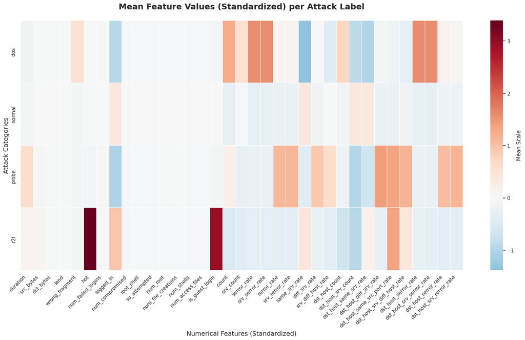

```
Successfully saved: expert_reports/attack_std_analysis.pdf
```

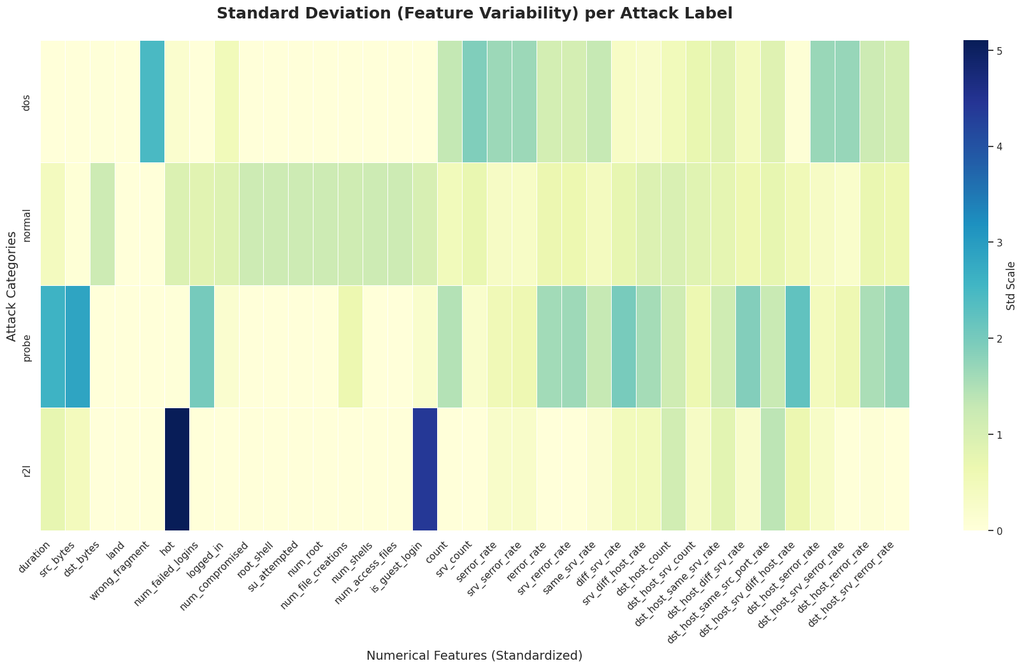

```
Successfully saved: expert_reports/attack_median_analysis.pdf
```

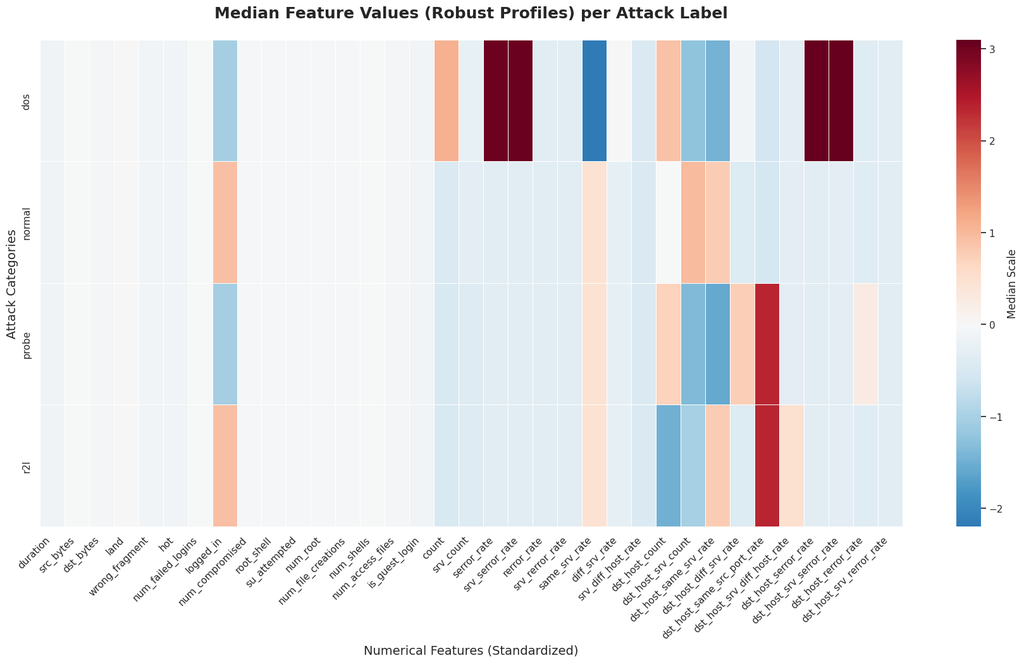

```python
generate_and_save_expert_heatmaps(df_train_preprocessed, numerical_cols)
```

# Task 2: Shallow Anomaly Detection- Supervised vs Unsupervised

## One-Class SVM with Normal data only: First, train a One-Class Support Vector Machine (OC-SVM) with benign (normal) traffic only using an rbf kernel. Then, evaluate the performance using all training data (normal + anomalies).

### check the proportion of anomalies w.r.t. normal data

```python
res = df_train_preprocessed.value_counts("binary_label")
print("normal samples:", res[0])
print("anomalous samples:", res[1])
anomaly_rate = res[1]/(res[0]+res[1])
print("The fraction of anomalies in the dataset is %.2f"%anomaly_rate)
```

```
normal samples: 12103
anomalous samples: 4814
The fraction of anomalies in the dataset is 0.28
```

### keep only normal rows in dataset

```python
# Prepare data for training and validation just for normal samples (binary_label == 0)
print("Preparing data for O-SVM training (normal samples only)...")
print("df_train_preprocessed columns:", df_train_preprocessed.shape)
df_train_normal_only = df_train_preprocessed[df_train_preprocessed["binary_label"]==0].copy()
X_train_normal_only = df_train_normal_only.drop(columns=['label', 'binary_label'])
y_train_normal_only = list(df_train_normal_only['binary_label'])
print(f"Training set (normal only) shape: {X_train_normal_only.shape}")

df_train_anomalous_only = df_train_preprocessed[df_train_preprocessed["binary_label"]==1].copy()
X_train_anomalous_only = df_train_anomalous_only.drop(columns=['label', 'binary_label'])
y_train_anomalous_only = list(df_train_anomalous_only['binary_label'])
print(f"Training set (anomalous only) shape: {X_train_anomalous_only.shape}")

df_val_normal_only = df_val_preprocessed[df_val_preprocessed["binary_label"]==0].copy()
X_val_normal_only = df_val_normal_only.drop(columns=['label', 'binary_label'])
y_val_normal_only = list(df_val_normal_only['binary_label'])

X_train = df_train_preprocessed.drop(columns=['label', 'binary_label'])
y_original_train = list(df_train_preprocessed['label'])
y_train = list(df_train_preprocessed['binary_label'])
print(f"Full training set shape: {X_train.shape}")
X_val = df_val_preprocessed.drop(columns=['label', 'binary_label'])
y_original_val = list(df_val_preprocessed['label'])
y_val = list(df_val_preprocessed['binary_label'])

X_test = df_test_preprocessed.drop(columns=['label', 'binary_label'])
y_original_test = list(df_test_preprocessed['label'])
y_test = list(df_test_preprocessed['binary_label'])
```

```
Preparing data for O-SVM training (normal samples only)...
df_train_preprocessed columns: (16917, 54)
Training set (normal only) shape: (12103, 52)
Training set (anomalous only) shape: (4814, 52)
Full training set shape: (16917, 52)
```

```python
from sklearn.metrics import classification_report, confusion_matrix
import seaborn as sns
import matplotlib.pyplot as plt

def plot_confusion_matrix(y_binary, y_pred, methodology, data_name):

    print("\nClassification Report (%s vs Ground Truth):", methodology)
    print(classification_report(y_binary, y_pred))

    # Confusion matrix
    cm = confusion_matrix(y_binary, y_pred)
    sns.heatmap(cm, annot=True, fmt='d', cmap='Blues', xticklabels=['Normal','Anomaly'], yticklabels=['Normal','Anomaly'])
    plt.title('Confusion Matrix %s with %s'%(data_name,methodology))
    plt.xlabel('Predicted')
    plt.ylabel('True')
    plt.show()
    plt.close()
```

### Anomaly Detection using SVM input data with normal data only - kind of "supervised"

### first let us try default parameter combination first

```python
#import OneClassSVM for anomaly detection
from sklearn.svm import OneClassSVM
```

```
Default nu parameter for OneClassSVM: 0.5

Classification Report (%s vs Ground Truth): O-SVM
              precision    recall  f1-score   support

           0       0.99      0.50      0.66     12103
           1       0.44      0.99      0.61      4814

    accuracy                           0.64     16917
   macro avg       0.72      0.74      0.64     16917
weighted avg       0.83      0.64      0.65     16917
```

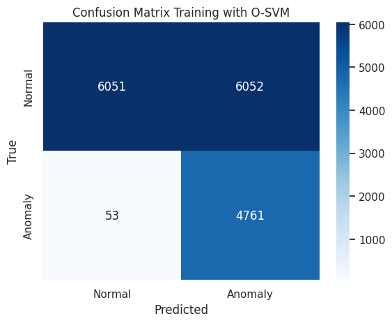

```python
default_ocsvm_nu = OneClassSVM().nu
print(f"Default nu parameter for OneClassSVM: {default_ocsvm_nu}")

# === 1. Fit One-Class SVM ===
# Assume X_train is your input data (numpy array or DataFrame with features only)
ocsvm_normal_only_default_nu = OneClassSVM(kernel='rbf', gamma='scale', nu=default_ocsvm_nu)  # nu = expected anomaly proportion - only normal data
ocsvm_normal_only_default_nu.fit(X_train_normal_only)

# === 2. Inference ===
# Predict returns 1 for inliers, -1 for outliers
# Convert to binary anomaly labels: 1 = anomaly, 0 = normal
y_train_pred = ocsvm_normal_only_default_nu.predict(X_train)
y_train_pred_binary = (y_train_pred == -1).astype(int)
plot_confusion_matrix(y_train, y_train_pred_binary, "O-SVM", "Training")
```

### set nu as estimated

```
Testing Nu   | F1-Score   | Note
----------------------------------------
0.001        | 0.8566     | Best result
0.010        | 0.8516     |
0.050        | 0.8570     | Best result
0.100        | 0.8190     |
0.200        | 0.7590     |

Optimization complete. Recommended nu: 0.05
Optimal nu found: 0.05

Classification Report (%s vs Ground Truth): OC-SVM (nu=0.05)
              precision    recall  f1-score   support

           0       0.94      0.95      0.94     12103
           1       0.87      0.84      0.86      4814

    accuracy                           0.92     16917
   macro avg       0.90      0.90      0.90     16917
weighted avg       0.92      0.92      0.92     16917
```

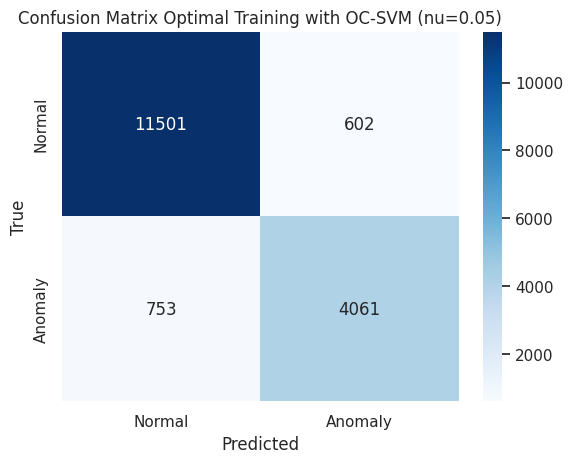

```python
import numpy as np
from sklearn.svm import OneClassSVM
from sklearn.metrics import f1_score, classification_report

def find_optimal_nu(X_train_normal, X_val, y_val, nu_list):
    """
    Iterates through a list of nu values to find the one that yields the highest F1-Score.

    Parameters:
    X_train_normal: Training data containing only 'normal' samples (with potential noise).
    X_val: Validation data containing both normal and anomaly samples.
    y_val: True labels for the validation set (0 for normal, 1 for anomaly).
    nu_list: A list of nu values to test.
    """
    best_nu = None
    best_f1 = -1

    print(f"{'Testing Nu':<12} | {'F1-Score':<10} | {'Note'}")
    print("-" * 40)

    for nu in nu_list:
        # Initialize OC-SVM with the current nu estimate
        # nu represents the upper bound on the fraction of training errors (noise)
        model = OneClassSVM(kernel='rbf', gamma='scale', nu=nu)

        # Train only on data labeled as 'normal'
        model.fit(X_train_normal)

        # Predict on validation data: 1 for inliers (normal), -1 for outliers (anomaly)
        y_pred_raw = model.predict(X_val)

        # Convert predictions to binary: 1 for anomaly, 0 for normal
        y_pred_binary = (y_pred_raw == -1).astype(int)

        # Calculate F1-Score to balance Precision and Recall
        current_f1 = f1_score(y_val, y_pred_binary)

        status = ""
        if current_f1 > best_f1:
            best_f1 = current_f1
            best_nu = nu
            status = "Best result"

        print(f"{nu:<12.3f} | {current_f1:<10.4f} | {status}")

    print(f"\nOptimization complete. Recommended nu: {best_nu}")
    return best_nu

# --- Execution ---

# 1. Define the range for nu based on the expected noise/error rate in normal data
nu_candidates = [0.001, 0.01, 0.05, 0.1, 0.2]

# 2. Find the best nu using your validation set
# Note: Ensure y_train/y_val uses 1 for Anomaly and 0 for Normal
optimal_nu = find_optimal_nu(X_train_normal_only, X_train, y_train, nu_list=nu_candidates)
print(f"Optimal nu found: {optimal_nu}")
# 3. Train the final model using the optimal nu
ocsvm_normal_best_nu = OneClassSVM(kernel='rbf', gamma='scale', nu=optimal_nu)
ocsvm_normal_best_nu.fit(X_train_normal_only)

# 4. Generate final predictions for visualization
train_preds = (ocsvm_normal_best_nu.predict(X_train) == -1).astype(int)

# 5. Plot the final confusion matrix using your existing function
plot_confusion_matrix(y_train, train_preds, f"OC-SVM (nu={optimal_nu})", "Optimal Training")
```

## One-Class SVM with All data: NowtraintheOC-SVM with both normal and anomalous data. Estimate nu as the ratio of anomalous data across the entire collection. Then,evaluate the performance using all training data (normal + anomalies).

```
Training O-SVM with nu = 0.2846 (estimated anomaly proportion in training data)

Classification Report (%s vs Ground Truth): O-SVM
              precision    recall  f1-score   support

           0       0.85      0.85      0.85     12103
           1       0.62      0.62      0.62      4814

    accuracy                           0.79     16917
   macro avg       0.74      0.74      0.74     16917
weighted avg       0.79      0.79      0.79     16917
```

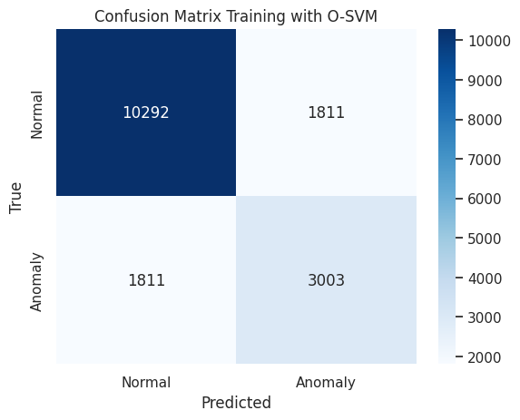

```python
# === 1. Fit One-Class SVM ===
# Assume X_train is your input data (numpy array or DataFrame with features only)
print(f"Training O-SVM with nu = {anomaly_rate:.4f} (estimated anomaly proportion in training data)")
ocsvm_all = OneClassSVM(kernel='rbf', gamma='scale', nu=anomaly_rate)  # nu = estimated anomaly proportion
ocsvm_all.fit(X_train)

# === 2. Inference ===
# Predict returns 1 for inliers, -1 for outliers
# Convert to binary anomaly labels: 1 = anomaly, 0 = normal

y_train_pred = ocsvm_all.predict(X_train)
y_train_pred_binary = (y_train_pred == -1).astype(int)
plot_confusion_matrix(y_train, y_train_pred_binary, "O-SVM", "Training")
```

## One-Class SVM with normal traffic and some anomalies: Evaluate the impact of the percentage of anomalies while training the OC-SVM. Train several OC-SVMs with an increasing subsample of anomalous classes ([0%, 10%, 20%, 50%, 100% ] of anomalies). Estimate the nu parameter for each scenario. Then, evaluate each model using all training data (normal + anomalies).

```python
import numpy as np
from sklearn.svm import OneClassSVM
from sklearn.metrics import classification_report, f1_score, accuracy_score

def run_ocsvm_contamination_experiment(X_train_normal, X_train_anomalies, X_train, y_train):
    """
    Evaluates how varying levels of anomaly contamination in the training set
    affect the performance of One-Class SVM.
    """
    # 1. Define the percentage of the anomaly pool to inject into the training set
    ratios = [0.0, 0.1, 0.2, 0.5, 1.0]
    results = []

    print(f"{'Ratio':>10} | {'Nu':>10} | {'Accuracy':>10} | {'Macro F1':>10}")
    print("-" * 60)

    for r in ratios:
        # 3. Subsample anomalies for the current training scenario
        num_anomalies = int(r * len(X_train_anomalies))
        X_anomaly_sub = X_train_anomalies[:num_anomalies]

        # Form the training set by mixing all normal data with a subset of anomalies
        X_train_current = np.concatenate([X_train_normal, X_anomaly_sub], axis=0)

        # 4. Estimate the nu parameter based on the current contamination ratio
        # If the training set is pure (ratio 0.0), we use 0.05 as a robust default
        nu_estimate = len(X_anomaly_sub) / len(X_train_current)
        if nu_estimate == 0:
            nu_estimate = 0.05

        # 5. Initialize and train the One-Class SVM model
        model = OneClassSVM(kernel='rbf', nu=nu_estimate, gamma='scale')
        model.fit(X_train_current)

        # 6. Perform inference on the full evaluation set
        y_pred = model.predict(X_train.values)
        y_pred_bin = (y_pred == -1).astype(int)
        # 7. Print the Classification Report for the current scenario
        print(f"\n[REPORT] Training Contamination Ratio: {r*100}% | Estimated Nu: {nu_estimate:.4f}")
        plot_confusion_matrix(y_train, y_pred_bin, "O-SVM", "Training")
        # 8. Calculate performance metrics
        # macro_f1 calculates the unweighted mean of F1 scores for both classes
        macro_f1 = f1_score(y_train, y_pred_bin, average='macro')
        acc = accuracy_score(y_train, y_pred_bin)

        print(f"Summary -> Acc: {acc:.44f} | Macro F1: {macro_f1:.4f}")
        print("-" * 60)

        results.append({
            'ratio': r,
            'nu': nu_estimate,
            'macro_f1': macro_f1,
            'acc': acc,
            'model': model
        })

    return results
```

```python
import matplotlib.pyplot as plt


def plot_ocsvm_contamination_results(results):
    """Plots the Macro F1-score against the anomaly contamination ratio with maximized text clarity."""
    ratios = [res["ratio"] for res in results]
    f1_scores = [res["macro_f1"] for res in results]

    plt.figure(figsize=(10, 6))

    # Premium academic styling: deep palette with highlighted markers
    plt.plot(
        ratios,
        f1_scores,
        marker="o",
        linestyle="-",
        color="#2c3e50",
        linewidth=3,
        markersize=10,
        markerfacecolor="#3498db",
        markeredgewidth=1.5,
    )

    # Global font size updates
    plt.title(
        "Impact of Training Set Contamination on OC-SVM (Macro F1)",
        fontsize=16,
        fontweight="bold",
        pad=20,
    )
    plt.xlabel(
        "Anomaly Contamination Ratio in Training Set", fontsize=14, labelpad=12
    )
    plt.ylabel("Macro F1-Score", fontsize=14, labelpad=12)

    # --- CRITICAL FIX: Maximize tick number sizes ---
    plt.xticks(fontsize=13, fontweight="semibold")
    plt.yticks(fontsize=13, fontweight="semibold")

    # Give the top label more breathing room
    plt.ylim(0, 1.08)

    # Softer grid line architecture
    plt.grid(True, linestyle="--", alpha=0.6, color="#b2bec3")

    # --- CRITICAL FIX: Maximize data label number sizes ---
    for i, txt in enumerate(f1_scores):
        plt.annotate(
            f"{txt:.4f}",
            (ratios[i], f1_scores[i]),
            textcoords="offset points",
            xytext=(0, 14),  # Pushed slightly higher to avoid overlapping the larger marker
            ha="center",
            fontsize=13,
            fontweight="bold",
            color="#2c3e50",
        )

    plt.tight_layout()

    # Save high-resolution outputs
    plt.savefig("ocsvm_contamination_trend.png", dpi=300)
    plt.savefig("contamination_plot.pdf", dpi=300)
    plt.show()
```

```
     Ratio |         Nu |   Accuracy |   Macro F1
------------------------------------------------------------

[REPORT] Training Contamination Ratio: 0.0% | Estimated Nu: 0.0500

Classification Report (%s vs Ground Truth): O-SVM
              precision    recall  f1-score   support

           0       0.94      0.95      0.94     12103
           1       0.87      0.84      0.86      4814

    accuracy                           0.92     16917
   macro avg       0.90      0.90      0.90     16917
weighted avg       0.92      0.92      0.92     16917
```

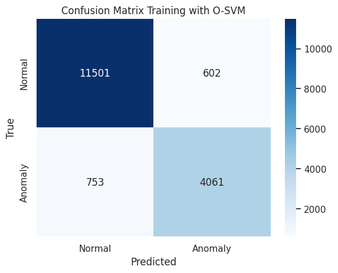

```
Summary -> Acc: 0.91990305609741684911284664849517866969108582 | Macro F1: 0.9007
------------------------------------------------------------

[REPORT] Training Contamination Ratio: 10.0% | Estimated Nu: 0.0382

Classification Report (%s vs Ground Truth): O-SVM
              precision    recall  f1-score   support

           0       0.77      0.97      0.86     12103
           1       0.79      0.27      0.40      4814

    accuracy                           0.77     16917
   macro avg       0.78      0.62      0.63     16917
weighted avg       0.78      0.77      0.73     16917
```

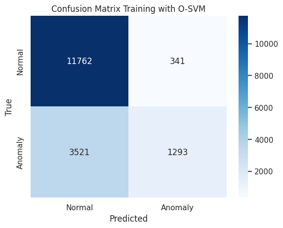

```
Summary -> Acc: 0.77170893184370747963640724265133030712604523 | Macro F1: 0.6300
------------------------------------------------------------

[REPORT] Training Contamination Ratio: 20.0% | Estimated Nu: 0.0736

Classification Report (%s vs Ground Truth): O-SVM
              precision    recall  f1-score   support

           0       0.78      0.95      0.86     12103
           1       0.73      0.34      0.47      4814

    accuracy                           0.78     16917
   macro avg       0.76      0.65      0.66     16917
weighted avg       0.77      0.78      0.75     16917
```

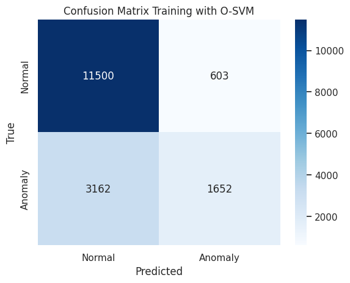

```
Summary -> Acc: 0.77744280900868945050063985036103986203670502 | Macro F1: 0.6634
------------------------------------------------------------

[REPORT] Training Contamination Ratio: 50.0% | Estimated Nu: 0.1659

Classification Report (%s vs Ground Truth): O-SVM
              precision    recall  f1-score   support

           0       0.83      0.90      0.86     12103
           1       0.68      0.52      0.59      4814

    accuracy                           0.79     16917
   macro avg       0.75      0.71      0.73     16917
weighted avg       0.78      0.79      0.78     16917
```

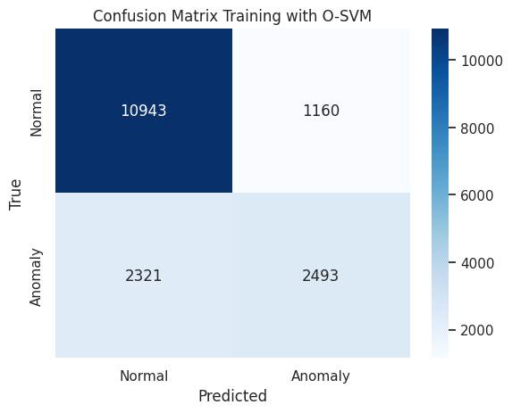

```
Summary -> Acc: 0.79423065555358518530226774601032957434654236 | Macro F1: 0.7258
------------------------------------------------------------

[REPORT] Training Contamination Ratio: 100.0% | Estimated Nu: 0.2846

Classification Report (%s vs Ground Truth): O-SVM
              precision    recall  f1-score   support

           0       0.85      0.85      0.85     12103
           1       0.62      0.62      0.62      4814

    accuracy                           0.79     16917
   macro avg       0.74      0.74      0.74     16917
weighted avg       0.79      0.79      0.79     16917
```

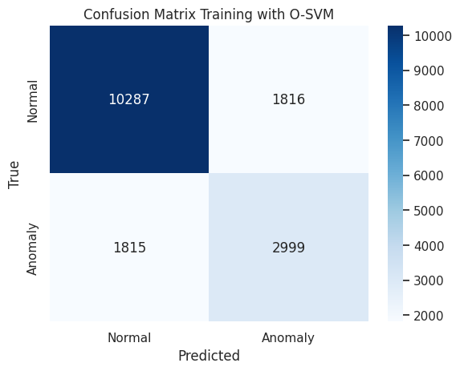

```
Summary -> Acc: 0.78536383519536556718776409979909658432006836 | Macro F1: 0.7364
------------------------------------------------------------

Experiment completed. Summary of results:
Ratio: 0.00 | Nu: 0.0500 | Accuracy: 0.9199 | Macro F1: 0.9007
Ratio: 0.10 | Nu: 0.0382 | Accuracy: 0.7717 | Macro F1: 0.6300
Ratio: 0.20 | Nu: 0.0736 | Accuracy: 0.7774 | Macro F1: 0.6634
Ratio: 0.50 | Nu: 0.1659 | Accuracy: 0.7942 | Macro F1: 0.7258
Ratio: 1.00 | Nu: 0.2846 | Accuracy: 0.7854 | Macro F1: 0.7364
```

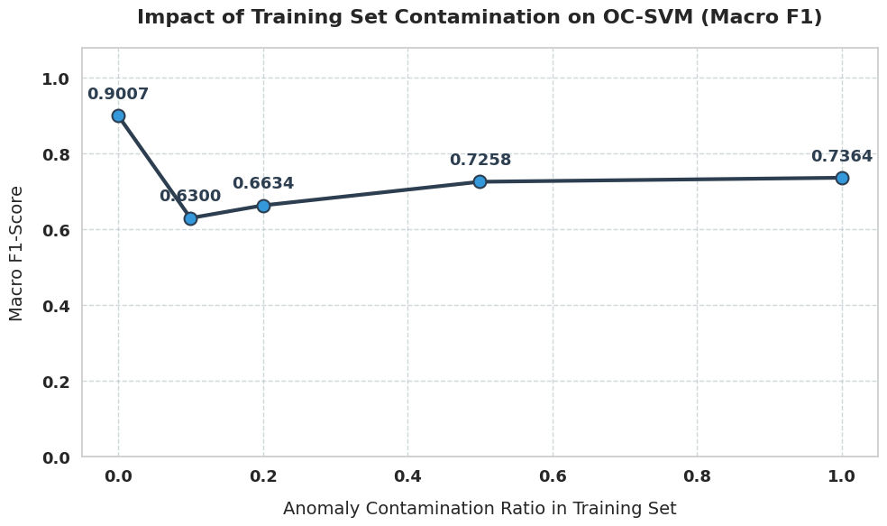

```python
results = run_ocsvm_contamination_experiment(X_train_normal_only, X_train_anomalous_only, X_train, y_train)
print("\nExperiment completed. Summary of results:")
for res in results:
    print(f"Ratio: {res['ratio']:.2f} | Nu: {res['nu']:.4f} | Accuracy: {res['acc']:.4f} | Macro F1: {res['macro_f1']:.4f}")
plot_ocsvm_contamination_results(results)
```